# Moderator analyses

# Overview

This file visualises the distribution of effect sizes across the moderators, and then conducts moderation tests using univariate analyses, meta-regression and meta-CART approaches.

```r
# For reproducibility package versions are locked to a specific date
if (!require(groundhog)) install.packages('groundhog')
groundhog::groundhog.library(c("readxl", "metaforest", "metafor", "tidyverse", "clubSandwich", "cli", "rsprite2", "esc", "ggtext",
                               "mice", "mitools", "metacart", "gt", "gtExtras", "psych", "furrr", "progressr", "micemd", "boot",
                               "cli"), date = "2023-07-09")
groundhog::groundhog.library(c("lukaswallrich/timesaveR"), date = "2023-07-09")

# Need more recent version of patchwork due to faceting bug
groundhog::groundhog.library(c("patchwork"), date = "2023-07-09")

source("helpers/metacart_fix.R") # metacart broke with R 4.2.0 due to a change in if-statement evaluation. This fix changes `class ==` to `inherits()`
source("helpers/metacart_plot.R")

source("helpers/helpers.R")
source("helpers/equivalence_testing.R")

# Prepare to display progress
handlers(
  handler_cli()
)

options(cli.progress_show_after = 0)
options(cli.progress_clear = FALSE)

dataset <- read_rds("data/full_dataset.rds")
# Assumed correlation between dependent effect sizes
rho <- 0.6
```

## Distribution of effect sizes

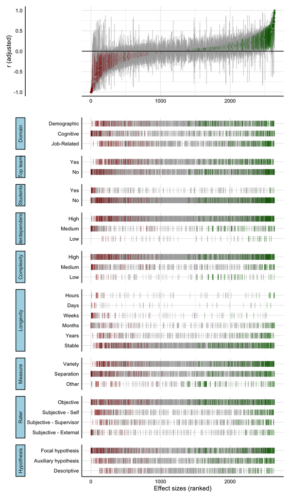

```r
# Get confidence intervals based on the adjusted standard errors (for effective sample size and unreliability)
get_cis <- function(r_adj, adjustment_ratio, n, conf.level = 0.95) {

  # Reduce extreme estimates to those that would be rounded
  if (r_adj == 1) r_adj <- .995
  if (r_adj == -1) r_adj <- -.995

    # Fisher's r to z transformation
  z <- 0.5 * log((1 + r_adj) / (1 - r_adj))

  alpha <- 1 - conf.level
  z.critical <- qnorm(1 - alpha / 2)

  se_adj <- (1 / sqrt(n - 3)) * adjustment_ratio

  # Confidence interval calculation
  ci.lower <- z - z.critical * se_adj
  ci.upper <- z + z.critical * se_adj

  # Transforming back to r
  ci.lower.r <- (exp(2 * ci.lower) - 1) / (exp(2 * ci.lower) + 1)
  ci.upper.r <- (exp(2 * ci.upper) - 1) / (exp(2 * ci.upper) + 1)

  list(ci_low = ci.lower.r, ci_high = ci.upper.r)
}

dataset_spec <- dataset %>%
  mutate(ci = pmap(list(r_adj, ifelse(r_adj == 0, 1, r_adj/r_rep), n_teams), get_cis)) %>%
  mutate(ci_low = map_dbl(ci, 1), ci_high = map_dbl(ci, 2)) %>%
  select(-ci) %>% arrange(r_adj) %>% rowid_to_column(var = "specification") %>%
  mutate(color = case_when(
    ci_high < 0 ~ "darkred",
    ci_low <= 0 ~ "darkgrey",
    ci_low > 0 ~ "darkgreen"
  ))

# Simplified code for creating the specification curve-type plot
# Derived from https://github.com/masurp/specr

  plot_a <- dataset_spec %>%
    ggplot(aes(x = specification, y = r_adj, ymin = ci_low, ymax = ci_high)) +
    geom_pointrange(aes(color = color), alpha = 0.5, size = 0.6, fatten = 1) +
    theme_minimal() +
    scale_color_identity() +
    theme(axis.line = element_line(linewidth = 0.5), legend.position = "none",
          panel.spacing = unit(0.75, "lines"), axis.text = element_text(color = "black")) +
    labs(x = "", y = "r (adjusted)") +
  geom_hline(yintercept = 0)

  choices <- c("Domain" = "domain", "Top team" = "tmt", "Students" = "stud_sample",
               "Interdependence" = "interdep", "Complexity" = "complexity", "Longevity" = "longevity",
               "Measure" = "meas_type", "Rater" = "rater", "Hypothesis" = "art_focus")

  rev_choices <- setNames(names(choices), choices)


 levels_replace <- tibble::tribble(
  ~level_old,                 ~level_new,
   "focal H",                  "Focal hypothesis",
   "auxiliary H",              "Auxiliary hypothesis",
   "descriptive",              "Descriptive",
   "high",                     "High",
   "medium",                   "Medium",
   "low",                      "Low",
   "yes",                      "Yes",
   "no",                       "No",
   "Variety",                  "Variety",
   "Separation",               "Separation",
   "Other",                    "Other",
   "Objective",                "Objective",
   "Subjective - self",        "Subjective - Self",
   "Subjective - supervisor",  "Subjective - Supervisor",
   "Subjective - external",    "Subjective - External",
   "hours",                    "Hours",
   "days",                     "Days",
   "weeks",                    "Weeks",
   "months",                   "Months",
   "years",                    "Years",
   "stable",                   "Stable",
   "Demographic",              "Demographic",
   "Cognitive",                "Cognitive",
   "Job-related",              "Job-Related"
) %>% {
  setNames(.$level_new, .$level_old)
}

  plot_b <- dataset_spec %>%
    mutate(sub_dom = fct_lump_n(sub_dom, 5)) %>%
    tidyr::gather(key = "key", value = "value", all_of(choices)) %>%
    mutate(key = coalesce(rev_choices[key], key),
           value = coalesce(levels_replace[value], value),
           key = factor(key, levels = rev_choices),
           value = factor(value, levels = levels_replace) %>% fct_rev()) %>%
    filter(!is.na(value)) %>%
ggplot(aes(x = specification, y = value, color = color)) +
    geom_point(shape = 124, size = 3.35, alpha = .5) +
    scale_color_identity() +
    theme_minimal() +
    facet_grid(key ~ ., scales = "free_y", space = "free_y", switch = "y") +
    theme(axis.line = element_line(linewidth = 0.5),
          legend.position = "none",
          panel.spacing = unit(0.75, "lines"),
          axis.text = element_text(color = "black"),
          strip.text.y.left = element_text(angle = 90),
          strip.background = element_rect(fill="lightblue", colour="black",linewidth = 1),
          strip.placement = "outside",
          strip.text.x = element_blank()) +
    labs(x = "Effect sizes (ranked)", y = "")


  # Combine both plots
  p <- plot_a / plot_b +
    plot_layout(heights = c(1, 4))

  ggsave("figures/distribution_of_effects.png", p, width = 23, height = 31, units = "cm")

  p
```

# Individually test moderators

For interpretability and comparability with earlier work, we started with univariate tests using the observed/coded data (which evidently results in different datasets for each moderator).

```r
cat_moderators <- c("complexity", "interdep", "longevity", "meas_type", "rater", "design", "art_focus", "criterion")
cont_moderators <- c("year_merged", "collectivism", "power_distance")
expl_mods <- c("country_grp", "tmt", "stud_sample", "ind_sector", "team_function", "domain_and_sub", "objective_rater")

# To rename for reporting
var_names <-  tibble::tribble(
  ~old,           ~new,
   "art_focus",    "Article focus",
   "pub_status",   "Publication status",
   "language",      "Language",
   "design",       "Design",
   "tmt",          "TMT",
   "stud_sample",  "Student sample",
   "meas_type",    "Diversity measure",
   "rater",        "Performance rater",
   "objective_rater",        "Objective rater",
   "criterion",        "Performance criterion",
   "interdep",     "Interdependence",
   "complexity",   "Complexity",
   "virtuality",   "Virtuality",
   "longevity",    "Longevity",
   "auth_diff",    "Authority Differentiation",
   "collectivism",  "Collectivism",
   "power_distance",    "Power distance",
   "ind_sector",    "Industry sector",
   "team_function",    "Team function",
   "country_grp",    "Country",
   "year_merged",    "Year of data collection",
   "domain_and_sub", "Sub-domain"
)

level_names <- tibble::tribble(
  ~var,           ~level_old,                 ~level_new,
   "art_focus",    "focal H",                  "Focal hypothesis",
   "art_focus",    "auxiliary H",              "Auxiliary hypothesis",
   "art_focus",    "descriptive",              "Descriptive",
   "pub_status",   "Published",                "Published",
   "pub_status",   "Masters Dissertation",          "Masters Dissertation",
   "pub_status",   "Working paper/Preprint",   "Working Paper/Preprint",
   "pub_status",   "Conference presentation",  "Conference Presentation",
   "pub_status",   "PhD Dissertation",         "PhD Dissertation",
   "interdep",     "high",                     "High",
   "interdep",     "medium",                   "Medium",
   "interdep",     "low",                      "Low",
   "complexity",   "high",                     "High",
   "complexity",   "medium",                   "Medium",
   "complexity",   "low",                      "Low",
   "tmt",          "yes",                      "Yes",
   "tmt",          "no",                       "No",
   "stud_sample",  "yes",                      "Yes",
   "stud_sample",  "no",                       "No",
   "meas_type",    "Variety",                  "Variety",
   "meas_type",    "Separation",               "Separation",
   "meas_type",    "Other",                    "Other",
   "design",       "Experimental",             "Experimental",
   "design",       "Observational",            "Observational",
   "objective_rater",        "Objective",                "Objective",
   "objective_rater",        "Subjective",        "Subjective",
  "rater",        "Objective",                "Objective",
   "rater",        "Subjective - self",        "Subjective - Self",
   "rater",        "Subjective - supervisor",  "Subjective - Supervisor",
   "rater",        "Subjective - external",    "Subjective - External",
   "virtuality",   "physical",                 "Physical",
   "virtuality",   "hybrid-members",           "Hybrid-Members",
   "virtuality",   "virtual",                  "Virtual",
   "auth_diff",    "high",                     "High",
   "auth_diff",    "mixed",                    "Mixed",
   "auth_diff",    "low",                      "Low",
   "language",  "chinese",     "Chinese",
   "language",  "dutch",       "Dutch",
   "language",  "english",     "English",
   "language",  "french",      "French",
   "language",  "german",      "German",
   "language",  "indonesian",  "Indonesian",
   "language",  "italian",     "Italian",
   "language",  "japanese",    "Japanese",
   "language",  "korean",      "Korean",
   "language",  "portuguese",  "Portuguese",
   "language",  "spanish",     "Spanish",
   "longevity",  "hours",    "Hours",
   "longevity",  "days",     "Days",
   "longevity",  "weeks",    "Weeks",
   "longevity",  "months",   "Months",
   "longevity",  "years",    "Years",
   "longevity",  "stable",   "Stable"
)

single_cat_moderator_test <- function(moderator, data, min_group_k = FALSE) {

  p <- progressor(7, message = paste("Now estimating", moderator))

  if (min_group_k) {
    data$`__mod__` <- data[[moderator]] # So that colname is known for use in dplyr pipe

    outs <- data %>%
      count(`__mod__`) %>%
      filter(n < min_group_k) %>%
      pull(`__mod__`)
    data$`__mod_dom__` <- paste0(data$`__mod__`, data$domain)
    domain_outs <- data %>%
      count(`__mod_dom__`) %>%
      filter(n < min_group_k) %>%
      pull(`__mod_dom__`)

    V <- with(
      data %>% filter(!data[[moderator]] %in% outs),
      impute_covariance_matrix(
        vi = var_adj,
        cluster = articlestudy,
        r = rho
      )
    )
    if (nrow(V) != nrow(data)) message("Excluded ", nrow(data) - nrow(V), " effect sizes with moderator levels below minimum group size")

    Vd <- with(
      data %>% filter(!data$`__mod_dom__` %in% domain_outs),
      impute_covariance_matrix(
        vi = var_adj,
        cluster = articlestudy,
        r = rho
      )
    )
    if (nrow(Vd) != nrow(data)) message("Excluded ", nrow(data) - nrow(Vd), " effect sizes with moderator-domain combinations below minimum group size")

    data <- data %>% filter(!data[[moderator]] %in% outs)
  } else {
    V <- with(
      data,
      impute_covariance_matrix(
        vi = var_adj,
        cluster = articlestudy,
        r = rho
      )
    )

    Vd <- V # Same matrix when there is no filtering
  }

  p()

  no_levels <- data[[moderator]] %>%
    unique() %>%
    na.omit() %>%
    length()

  mod <- {
    data[[moderator]] <- factor(data[[moderator]], ordered = FALSE)

    mod <- rma.mv(as.formula(paste0("r_adj ~ 0 + ", moderator)),
      V = V,
      random = ~ 1 | articlestudy / effect_id,
      test = "t",
      dfs = "contain",
      data = data,
      sparse = TRUE
    )
    p()
```

```r
    if (min_group_k) data <- data %>% filter(!data$`__mod_dom__` %in% domain_outs)

    mod_domain_no_int <- rma.mv(as.formula(paste0("r_adj ~ 0 + domain:", moderator)),
      V = Vd,
      random = ~ 1 | articlestudy / effect_id,
      test = "t",
      dfs = "contain",
      data = data,
      sparse = TRUE
    )
    p()
    list(
      mod = mod,
      mod_domains_no_int = mod_domain_no_int
    )
  }
  robust_across <- coef_test(mod$mod, vcov = "CR2")
  robust_domain_no_int <- coef_test(mod$mod_domains_no_int, vcov = "CR2")

  if (nrow(robust_across) > 20) message("Moderator has large number of levels - wald_test may take several minutes.")

  # Test of moderator overall
  res_tibble <- Wald_test(mod$mod, vcov = "CR2", constrain_equal(1:nrow(robust_across), coef(mod$mod))) %>% mutate(domain = "Overall")
  p()

  # Test of domains
  if (no_levels * 3 == nrow(robust_domain_no_int)) {
    for (i in 1:3) {
      res_tibble <- bind_rows(res_tibble, Wald_test(mod$mod_domains_no_int, vcov = "CR2", constrain_equal(seq(i, no_levels * 3, by = 3), coef(mod$mod_domains_no_int))) %>%
        mutate(domain = names(coef(mod$mod_domains_no_int))[i] %>% str_extract("[A-z]*")))
      p()
    }
  } else {
    # Some levels did not exist in all domains - in these cases, need to match by coefficient names
    for (d in unique(data$domain)) {
      if (sum(str_detect(names(coef(mod$mod_domains_no_int)), d)) > 1) {
        # To allow to test domains themselves with this function
      res_tibble <- bind_rows(res_tibble, Wald_test(mod$mod_domains_no_int,
        vcov = "CR2",
        constrain_equal(which(str_detect(names(coef(mod$mod_domains_no_int)), d)), coef(mod$mod_domains_no_int))
      ) %>%
        mutate(domain = d))
      } else {
        res_tibble
      }
      p()
    }
  }
  list(moderator_test = res_tibble, robu_averages = robust_across, robu_domain_no_int = robust_domain_no_int, meta_models = mod)
}

single_cont_moderator_test <- function(moderator, data) {

  p <- progressor(4, message = paste("Now estimating", moderator))

  V <- with(
    data,
    impute_covariance_matrix(
      vi = var_adj,
      cluster = articlestudy,
      r = rho
    )
  )
  p()
  mod <- {
    mod <- rma.mv(as.formula(paste0("r_adj ~ ", moderator)),
      V = V,
      random = ~ 1 | articlestudy / effect_id,
      test = "t",
      dfs = "contain",
      data = data,
      sparse = TRUE
    )
    p()
    mod_domains <- rma.mv(as.formula(paste0("r_adj ~ 0 + domain + domain:", moderator)),
      V = V,
      random = ~ 1 | articlestudy / effect_id,
      test = "t",
      dfs = "contain",
      data = data,
      sparse = TRUE
    )
    p()
    mod_domains_no_int <- rma.mv(as.formula(paste0("r_adj ~ 0 + domain:", moderator)),
      V = V,
      random = ~ 1 | articlestudy / effect_id,
      test = "t",
      dfs = "contain",
      data = data,
      sparse = TRUE
    )
    p()
    list(
      mod = mod,
      mod_domains = mod_domains,
      mod_domains_no_int = mod_domains_no_int
    )
  }

  list(
    robust_across = coef_test(mod$mod, vcov = "CR2"),
    robust_domain = coef_test(mod$mod_domains, vcov = "CR2"),
    robust_domain_no_int = coef_test(mod$mod_domains_no_int, vcov = "CR2"),
    meta_models = mod
  )
}

cat_plots <- function(cats, minimum_samples = NULL, data = dataset) {
  minart <- minimum_samples # Work around a promise evaluation error
  imap(cats, \(res, predictor_name, minimum_samples = minart) {
    all_coefs <- bind_rows(
      res$robu_domain_no_int %>% tibble(),
      res$robu_averages %>% tibble()
    )

    if (!is.null(minimum_samples)) {
      dataset_articles <- data %>%
        group_by(articlestudy, !!sym(predictor_name)) %>%
        slice_head(n = 1) %>%
        ungroup()

      all_vals <- dataset_articles[[predictor_name]] %>%
        unique() %>%
        na.omit()

      out_overall <- setdiff(
        all_vals,
        dataset_articles[[predictor_name]] %>% table() %>% as_tibble() %>% filter(n >= minimum_samples) %>% pull(1)
      ) %>% paste0(predictor_name, .)

      dataset_articles <- data %>%
        group_by(articlestudy, domain, !!sym(predictor_name)) %>%
        slice_head(n = 1) %>%
        ungroup()

      out_dem <- setdiff(
        all_vals,
        dataset_articles %>% filter(domain == "Demographic") %>% .[[predictor_name]] %>% table() %>%
          as_tibble() %>% filter(n >= minimum_samples) %>% pull(1)
      ) %>% paste0("domainDemographic:", predictor_name, .)

      out_job <- setdiff(
        all_vals,
        dataset_articles %>% filter(domain == "Job-related") %>% .[[predictor_name]] %>% table() %>%
          as_tibble() %>% filter(n >= minimum_samples) %>% pull(1)
      ) %>% paste0("domainJob-related:", predictor_name, .)

      out_cog <- setdiff(
        all_vals,
        dataset_articles %>% filter(domain == "Cognitive") %>% .[[predictor_name]] %>% table() %>%
          as_tibble() %>% filter(n >= minimum_samples) %>% pull(1)
      ) %>% paste0("domainCognitive:", predictor_name, .)

      all_out <- c(out_overall, out_dem, out_job, out_cog)

      all_coefs <- all_coefs %>% filter(!Coef %in% all_out)
    }

    cur_levels <- level_names %>% filter(var == predictor_name)
df_preprocessed <- all_coefs %>%
  mutate(domain = coalesce(str_extract(Coef, "domain[^:]+") %>% str_remove("domain"), "**Overall**"),
         Coef = str_remove(Coef, paste0(".*", predictor_name))) %>%
  select(coef = Coef, beta = beta, se = SE, df = df_Satt, p = p_Satt, domain)

if (nrow(cur_levels) > 0) {
  df_preprocessed <- df_preprocessed %>%
    rowwise() %>%
    mutate(coef = cur_levels$level_new[cur_levels$level_old == coef] %>% factor(levels = rev(cur_levels$level_new))) %>%
    ungroup()
}

df_preprocessed <- df_preprocessed %>%
  mutate(y = as.numeric(factor(paste(domain, coef))),
         ci_label = paste(fmt_cor(beta), fmt_ci(beta - 1.96 * se, beta + 1.96 * se, drop_0 = TRUE)))


# Create the plot with annotations and secondary y-axis labels
p <- ggplot(df_preprocessed, aes(y = y, x = beta, color = domain)) +
  geom_point() +
  geom_errorbarh(aes(xmin = beta - 1.96 * se, xmax = beta + 1.96 * se), height = 0.2) +
  geom_vline(xintercept = 0, linetype = "dashed", linewidth = .5) +
  geom_vline(xintercept = c(-.1, .1), linetype = "dotted", linewidth = .5) +
  facet_wrap(~domain, scales = "free_y", ncol = 1) +
  theme_minimal() +
  labs(x = "", y = "",
       subtitle = var_names$new[var_names$old == predictor_name]) +
  theme(axis.text.y = element_text(angle = 0, hjust = 1, size = rel(1)),
        strip.text = element_markdown()) +
  scale_color_brewer(palette = "Set1") +
  scale_fill_brewer(palette = "Set1") +
  theme(legend.position = "none",
        axis.text.y.right = element_text(hjust = 1)) +
  scale_y_continuous(
    breaks = df_preprocessed$y,
    labels = df_preprocessed$coef,
    sec.axis = sec_axis(~ ., breaks = df_preprocessed$y, labels = df_preprocessed$ci_label)
  )
```

```r
list(plot = p, coefs = df_preprocessed)
  })
}

# Bootstrap (pseudo) R2 confidence intervals based on guidance by Wolfgang Viechtbauer
# https://www.metafor-project.org/doku.php/tips:ci_for_r2
# https://gist.github.com/wviechtb/6fbfca40483cb9744384ab4572639169
# Showed that for this, BCa CIs are best

boot_R2 <- function(dat, indices, moderator, other_moderators = NULL, progress = TRUE) {
  if (progress) p()

  data <- dat[indices, ]

  # Drop rows where moderator or any of other_moderators are NA
  if (!is.null(other_moderators)) {
    data <- data %>% drop_na(all_of(c(moderator, other_moderators)))
  } else {
    data <- data %>% drop_na(all_of(moderator))
  }

  # Null models for R2
  V <- with(
    data,
    impute_covariance_matrix(
      vi = var_adj,
      cluster = articlestudy,
      r = rho
    )
  )

  if (!is.null(other_moderators)) {
    fml <- paste("r_adj ~", paste(other_moderators, collapse = " + "))
  } else {
    fml <- "r_adj ~ 1"
  }


  mod_null <- try(suppressWarnings(rma.mv(as.formula(fml),
    V = V,
    random = ~ 1 | articlestudy / effect_id,
    test = "t",
    dfs = "contain",
    data = data,
    sparse = TRUE
  )))

  mod_moderated <- try(suppressWarnings(rma.mv(as.formula(paste(fml, moderator, sep = " + ")),
    V = V,
    random = ~ 1 | articlestudy / effect_id,
    test = "t",
    dfs = "contain",
    data = data,
    sparse = TRUE
  )))

  if (inherits(mod_null, "try-error") || inherits(mod_moderated, "try-error")) {
    NA
  } else {
    if (sum(mod_null$sigma2) > 0) {
      max(0, 100 * (sum(mod_null$sigma2) - sum(mod_moderated$sigma2)) / sum(mod_null$sigma2))
    } else {
      # catch cases where sum(res0$sigma2) is 0, to avoid -Inf (if sum(res1$sigma2)
      # is positive) or NaN (if sum(res1$sigma2) is also 0) for R^2; for such cases,
      # define R^2 to be 0
      0
    }
  }
}
```

```r
dataset$objective_rater <- fct_collapse(dataset$rater, "Objective" = "Objective",
                                        "Subjective" = c("Subjective - self", "Subjective - supervisor", "Subjective - external"))

if (file.exists("data/single_cat_moderator_tests.qs")) {
  single_cat_moderator_tests <- qs::qread("data/single_cat_moderator_tests.qs")
  if (any(names(single_cat_moderator_tests) != cat_moderators)) {
    warning("File on disk does not match current list of moderators. Consider deleting it to re-estimate.")
  }
} else {
  single_cat_moderator_tests <- with_progress({
    cat_moderators %>%
      set_names() %>%
      map(\(moderator) single_cat_moderator_test(moderator, dataset))
  })
  qs::qsave(single_cat_moderator_tests, "data/single_cat_moderator_tests.qs")
}

if (file.exists("data/single_cont_moderator_tests.qs")) {
  single_cont_moderator_tests <- qs::qread("data/single_cont_moderator_tests.qs")
  if (any(names(single_cont_moderator_tests) != cont_moderators)) {
    warning("File on disk does not match current list of moderators. Consider deleting it to re-estimate.")
  }
} else {
  single_cont_moderator_tests <- with_progress({
    cont_moderators %>%
      set_names() %>%
      map(\(moderator) single_cont_moderator_test(moderator, dataset))
  })
  qs::qsave(single_cont_moderator_tests, "data/single_cont_moderator_tests.qs")
}

# Collapse countries so that there are at least 3 per group (otherwise, group estimates too noisy
# and Wald test fails to converge with more than 30 levels)
dataset <- dataset %>% mutate(
  country_grp = fct_lump_min(country, 3),
  domain_and_sub = paste(domain, sub_dom)
)

if (file.exists("data/single_expl_cat_moderator_tests.qs")) {
  single_expl_cat_moderator_tests <- qs::qread("data/single_expl_cat_moderator_tests.qs")
  if (any(names(single_expl_cat_moderator_tests) != expl_mods)) {
    warning("File on disk does not match current list of moderators. Consider deleting it to re-estimate.")
  }
} else {
  single_expl_cat_moderator_tests <- with_progress({
    expl_mods %>%
      set_names() %>%
      map(\(moderator) single_cat_moderator_test(moderator, dataset, min_group_k = 3))
  })
  qs::qsave(single_expl_cat_moderator_tests, "data/single_expl_cat_moderator_tests.qs")
}

cat_summary <- single_cat_moderator_tests %>%
  map_dfr("moderator_test", .id = "moderator") %>%
  mutate(
    domain = str_remove(domain, "domain"),
    domain = case_when(
      domain == "Job" ~ "Job-related",
      TRUE ~ domain
    )
  )

cont_summary <- bind_rows(
  single_cont_moderator_tests %>% map_dfr("robust_across", .id = "moderator") %>% as_tibble() %>% mutate(domain = "Overall") %>% filter(Coef != "intrcpt"),
  single_cont_moderator_tests %>% map_dfr("robust_domain", .id = "moderator") %>% as_tibble() %>% filter(str_detect(Coef, ":")) %>%
    mutate(domain = str_extract(Coef, ".*:") %>% str_remove("domain") %>% str_remove(":"))
)

cat_exp_summary <- single_expl_cat_moderator_tests %>%
  map_dfr("moderator_test", .id = "moderator") %>%
  mutate(
    domain = str_remove(domain, "domain"),
    domain = case_when(
      domain == "Job" ~ "Job-related",
      TRUE ~ domain
    )
  )

ks <- single_cat_moderator_tests %>%
  map_dbl(~ .x$meta_models$mod_domains$k) %>%
  tibble(moderator = names(single_cat_moderator_tests), k = .) %>%
  bind_rows(single_cont_moderator_tests %>% map_dbl(~ .x$meta_models$mod_domains$k) %>% tibble(moderator = names(single_cont_moderator_tests), k = .)) %>%
  bind_rows(single_expl_cat_moderator_tests %>% map_dbl(~ .x$meta_models$mod_domains$k) %>% tibble(moderator = names(single_expl_cat_moderator_tests), k = .)) %>%
  rowwise() %>%
  mutate(moderator = var_names$new[var_names$old == moderator]) %>%
  ungroup()

Ns <- map_dfr(c(cat_moderators, cont_moderators, expl_mods), function(mod) {
  dataset %>%
    filter(!is.na(!!rlang::sym(mod))) %>%
    distinct(articlestudy) %>%
    summarise(moderator = mod, Ns = n())
}) %>%
  rowwise() %>%
  mutate(moderator = var_names$new[var_names$old == moderator]) %>%
  select(moderator, Ns)
```

The code to bootstrap R2s for the moderators (for equivalence testing) is very slow - it takes about 7-8 hours per moderator on an M2 Macbook Air. Therefore, it was run on AWC EC2 instances. The code used is found in `helpers/aws_code R2.R` but based on the code provided for reference below.

```r
# Run as background job
reg_mods <- c(cat_moderators, cont_moderators)

if (file.exists("data/bs_R2s_reg_mods.rds")) {
  bs_R2_reg_mods <- read_rds("data/bs_R2s_reg_mods.rds")
} else {
job::job("Bootstrapping R2 reg mods" = {
library(boot)
R <- 5000 # Needed for bca confidence intervals (see https://bugs.r-project.org/show_bug.cgi?id=18647), though that takes 7-8h per moderator (M2 Macbook)
system.time({
  bs_R2s <- reg_mods %>% set_names() %>% map(\(moderator) {
    set.seed(1234)
    if (!file.exists(glue::glue("data/bs_R2s_{moderator}.rds"))) {
      message("Now bootstrapping ", moderator)
      bs <- boot(dataset, boot_R2, R=R, moderator = moderator, ncpus = 6, parallel = "multicore")
      write_rds(bs, glue::glue("data/bs_R2s_{moderator}.rds"))
      bs
    } else {
      read_rds(glue::glue("data/bs_R2s_{moderator}.rds"))
    }

  })
})
write_rds(bs_R2s, "data/bs_R2s_reg_mods.rds")
}, import = c(rho, dataset, boot_R2, reg_mods))
   message("Registered R2s will be bootstrapped now in background job - rerun this chunk afterwards to load them. Note that this is very slow.")
}

if (file.exists("data/bs_R2s_expl_mods.rds")) {
  bs_R2_expl_mods <- read_rds("data/bs_R2s_expl_mods.rds")
} else {
job::job("Bootstrapping R2 reg mods" = {
library(boot)
R <- 5000 # Needed for bca confidence intervals (see https://bugs.r-project.org/show_bug.cgi?id=18647), though that takes 7-8h per moderator (M2 Macbook)
system.time({
  bs_R2s <- expl_mods %>% set_names() %>% map(\(moderator) {
    set.seed(1234)
    if (!file.exists(glue::glue("data/bs_R2s_{moderator}.rds"))) {
      message("Now bootstrapping ", moderator)
      bs <- boot(dataset, boot_R2, R=R, moderator = moderator, progress = FALSE, ncpus = 5, parallel = "multicore")
      write_rds(bs, glue::glue("data/bs_R2s_{moderator}.rds"))
      bs
    } else {
      read_rds(glue::glue("data/bs_R2s_{moderator}.rds"))
    }

  })
})
write_rds(bs_R2s, "data/bs_R2s_expl_mods.rds")
}, import = c(rho, dataset, boot_R2, expl_mods))
   message("Exploratory R2s will be bootstrapped now in background job - rerun this chunk afterwards to load them. Note that this is very slow.")
}
```

```r
library(boot)

if (!file.exists("data/mod_R2_equivalence.qs")) {
  job::job("Equivalence testing for moderator R2s" = {
    mod_R2s <- imap_dfr(bs_R2_reg_mods, .id = "moderator", \(R2s, moderator) {
  # Repeated calculation of bca confidence intervals takes ca. 10 mins per moderator
  cli::cli_alert_info("Now processing {moderator}")
  bs_type <- "bca"
  R2 <- R2s$t0
  ci <- try(extract_boot_ci(boot.ci(R2s, .95, type = "bca")), silent = TRUE)
  if (inherits(ci, "try-error")) {
    bs_type <- "perc"
  cli::cli_alert_warning("Could not estimate bca confidence interval for {moderator} - falling back to percentile.")
    ci <- boot.ci(R2s, .95, type = "perc") %>% extract_boot_ci()
  }
  p_equiv <- boot_get_equiv_p(R2s, 5, ci_type = bs_type)

  tibble(R2 = R2, R2_ci = glue::glue("[{round_(ci$CI_L, 2)}%, {round_(ci$CI_U, 2)}%]"), p_equiv = p_equiv, ci_list = list(ci))
})
      qs::qsave(mod_R2s, "data/mod_R2_equivalence.qs")
  })
  message("Equivalence testing for registered moderator R2s will be run now in background job - rerun this chunk afterwards to load them. This should take about 90 minutes.")
} else {
  mod_R2s <- qs::qread("data/mod_R2_equivalence.qs")
}

if (!file.exists("data/mod_R2_equivalence_expl.qs")) {
  job::job("Equivalence testing for exploratory moderator R2s" = {
    mod_R2s <- imap_dfr(bs_R2_expl_mods, .id = "moderator", \(R2s, moderator) {
  # Repeated calculation of bca confidence intervals takes ca. 10 mins per moderator
  cli::cli_alert_info("Now processing {moderator}")
  bs_type <- "bca"
  R2 <- R2s$t0
  ci <- try(extract_boot_ci(boot.ci(R2s, .95, type = "bca")), silent = TRUE)
  if (inherits(ci, "try-error")) {
    bs_type <- "perc"
  cli::cli_alert_warning("Could not estimate bca confidence interval for {moderator} - falling back to percentile.")
    ci <- boot.ci(R2s, .95, type = "perc") %>% extract_boot_ci()
  }
  p_equiv <- boot_get_equiv_p(R2s, 5, ci_type = bs_type)

  tibble(R2 = R2, R2_ci = glue::glue("[{round_(ci$CI_L, 2)}%, {round_(ci$CI_U, 2)}%]"), p_equiv = p_equiv, ci_list = list(ci))
})
      qs::qsave(mod_R2s, "data/mod_R2_equivalence_expl.qs")
  })
  message("Equivalence testing for exploratory moderator R2s will be run now in background job - rerun this chunk afterwards to load them. This should take about 90 minutes.")
} else {
  mod_R2s_expl <- qs::qread("data/mod_R2_equivalence_expl.qs")
}
```

```r
mod_R2s <-  bind_rows(mod_R2s, mod_R2s_expl)

mod_table <- bind_rows(cat_summary %>% select(moderator, p_val, domain),
          cont_summary %>% select(moderator, p_val = p_Satt, domain),
          cat_exp_summary %>% select(moderator, p_val, domain)) %>%
    left_join(mod_R2s, by = "moderator") %>%
  filter(moderator != "domain_and_sub") %>%
  rowwise() %>%
  mutate(p_fmt = paste(sigstars(p_val)) %>% str_replace_all("&dagger;", "†"), #.docx fails with this HTML code in body
         moderator = var_names$new[var_names$old == moderator]) %>%
    select(-p_val) %>%
  pivot_wider(names_from = "domain", values_from = "p_fmt") %>%
  left_join(ks, by = "moderator") %>%
  left_join(Ns, by = "moderator") %>%
  transmute(Moderator = moderator, Ns, k, Overall, Demographic, Cognitive, `Job-related`,
            `R<sup>2</sup>` = glue::glue("{round_(R2, 2)}% {R2_ci}"), `R<sup>2</sup> < 5%` = fmt_p(p_equiv, equal_sign = FALSE)) %>%
  gt::gt() %>%
  tab_header(title = "Univariate moderator tests") %>%
  tab_spanner(md("Significance tests"), Overall:`Job-related`) %>%
  tab_spanner(md("Overall effect size"),  id = "overall-spanner", `R<sup>2</sup>`:`R<sup>2</sup> < 5%`) %>%
   cols_label(.fn = md) %>%
  gt::tab_source_note(timesaveR:::std_stars %>% {glue::glue_collapse(paste(names(.),.), ", ")} %>% html()) %>%
  gt_apa_style(fmt_labels_md = TRUE)

gtsave(mod_table, "tables/moderator_tests.docx")

mod_table
```

Univariate moderator tests

| Moderator | Ns | k | Significance tests Overall | Significance tests Demographic | Significance tests Cognitive | Significance tests Job-related | Overall effect size R<sup>2</sup> | Overall effect size R<sup>2</sup> < 5% |
| --- | --- | --- | --- | --- | --- | --- | --- | --- |
| Complexity | 578 | 2393 |  |  | * | * | 0.00% [0.00%, 0.36%] | < .001 |
| Interdependence | 539 | 2229 |  |  |  |  | 0.89% [0.66%, 2.28%] | < .001 |
| Longevity | 542 | 2298 |  |  |  | * | 0.15% [0.00%, 0.75%] | < .001 |
| Diversity measure | 640 | 2609 |  |  |  |  | 0.04% [0.00%, 0.76%] | < .001 |
| Performance rater | 644 | 2623 |  |  |  | * | 0.00% [0.00%, 0.09%] | < .001 |
| Design | 646 | 2638 |  |  |  |  | 0.00% [0.00%, 1.06%] | < .001 |
| Article focus | 646 | 2638 | ** | * |  | † | 0.77% [0.49%, 1.84%] | < .001 |
| Performance criterion | 90 | 268 |  |  |  |  | 0.00% [0.00%, 4.36%] | .031 |
| Year of data collection | 646 | 2638 |  |  | † | * | 0.08% [0.00%, 0.63%] | < .001 |
| Collectivism | 549 | 2328 |  |  | ** |  | 0.20% [0.04%, 0.99%] | < .001 |
| Power distance | 549 | 2328 | * |  | * |  | 0.59% [0.23%, 2.16%] | < .001 |
| Country | 642 | 2596 |  | * |  |  | 3.91% [1.51%, 6.89%] | .392 |
| TMT | 646 | 2638 |  |  | † | * | 0.15% [0.01%, 0.96%] | < .001 |
| Student sample | 646 | 2638 |  |  |  |  | 0.09% [0.00%, 0.39%] | < .001 |
| Industry sector | 569 | 2397 |  |  |  |  | 2.19% [1.26%, 5.90%] | .257 |
| Team function | 596 | 2492 | * |  |  |  | 2.96% [2.56%, 5.13%] | .755 |
| Objective rater | 644 | 2623 |  | * |  | ** | 0.00% [0.00%, 0.07%] | < .001 |

† 0.1, * 0.05, ** 0.01, *** 0.001

```r
sig_mods <- c(single_cat_moderator_tests[c(1, 3, 7, 5)], single_expl_cat_moderator_tests[7], single_expl_cat_moderator_tests[2])[c(3, 1, 6, 2, 4, 5)]

many_cats <- single_expl_cat_moderator_tests[c(1, 4, 5)]

many_cats[[2]]$robu_domain_no_int <- many_cats[[2]]$robu_domain_no_int %>% mutate(Coef = str_replace(Coef, "Professional services.*", "Professional services"))

many_cats[[2]]$robu_averages <- many_cats[[2]]$robu_averages %>% mutate(Coef = str_replace(Coef, "Professional services.*", "Professional services"))


ns_mods <- c(single_cat_moderator_tests[c(2, 4, 6, 8)], single_expl_cat_moderator_tests[3])

main_plots <- cat_plots(sig_mods, minimum_samples = 5)
tall_plots <- cat_plots(many_cats, minimum_samples = 5)
ns_plots <- cat_plots(ns_mods, minimum_samples = 5)

p <- wrap_plots(map(main_plots, "plot"), tag_level = "new", heights = c(1, 2)) +
  plot_annotation(tag_levels = 'A', title = "Estimated correlations depending on moderator levels",
                  subtitle = "Estimated from univariate meta-regressions with cluster-robust standard errors",
                  caption = "95% confidence intervals shown with error bars. Dotted lines indicate thresholds for small effects (|r| < .1).")

p2 <- wrap_plots(map(tall_plots, "plot"), tag_level = "new") +
  plot_annotation(tag_levels = list(c('K', 'L', 'M')), title = "Estimated correlations depending on moderator levels",
                  subtitle = "Estimated from univariate meta-regressions with cluster-robust standard errors",
                  caption = "95% confidence intervals shown with error bars. Dotted lines indicate thresholds for small effects (|r| < .1).\nLevels (and domain-level combinations) based on fewer than 5 samples are not shown.")

p3 <- wrap_plots(map(ns_plots, "plot"), tag_level = "new") +
  plot_annotation(tag_levels = list(LETTERS[(which(LETTERS == "L") + 1):(which(LETTERS == "L")+1 + length(ns_plots))]), title = "Estimated correlations for non-significant moderators (in SM)",
                  subtitle = "Estimated from univariate meta-regressions with cluster-robust standard errors",
                  caption = "95% confidence intervals shown with error bars. Dotted lines indicate thresholds for small effects (|r| < .1).\nLevels (and domain-level combinations) based on fewer than 5 samples are not shown.")

coefs <- bind_rows(main_plots %>% map_dfr("coefs", .id = "moderator"),
                   tall_plots %>% map_dfr("coefs", .id = "moderator"),
                   ns_plots %>% map_dfr("coefs", .id = "moderator")) %>% select(moderator, domain, everything()) %>%
  rowwise() %>% mutate(moderator = var_names$new[var_names$old == moderator]) %>% ungroup()

ggsave("figures/moderated_estimates_cat.png", p, width = 13, height = 9)
ggsave("figures/moderated_estimates_tall.png", p2, width = 9, height = 11)

first_nna <- function(x) {
  x %>% na.omit() %>% .[1]
}

coefs %>%
  rename(`*r*` = beta, SE = se, zdf = df, `zz*p*` = p) %>%
  pivot_wider(names_from = "domain", values_from = c(`*r*`, SE, zdf, `zz*p*`), names_glue = "{domain}_{.value}") %>%
  select(-y, -ci_label) %>%
  group_by(moderator, coef) %>%
  summarise(across(everything(), first_nna), .groups = "drop") %>%
  select(moderator, coef, sort(names(.))) %>%
  group_by(moderator) %>%
  gt()  %>%
  tab_spanner_delim("_") %>%
  cols_label(coef = "") %>%
  cols_label(.list = stats::setNames(lapply(unlist(.$`_boxhead`$column_label),
            \(x) str_remove_all(x, "z") %>% md()), names(.$`_data`))) %>%
  fmt(columns = matches(fixed("*r*")), fns = \(x) fmt_cor(x, digits = 3)) %>%
  fmt(columns = matches(fixed("*p*")), fns = \(x) fmt_p(x, equal_sign = FALSE)) %>%
  fmt_number(columns = matches("df"), decimals = 0) %>%
  fmt_number(columns = matches("SE"), decimals = 2)  %>%
  sub_missing() %>%
  gt_apa_style() %>%
  cols_align("right", coef) %>%
  tab_header(title = "Estimated correlations for categorical moderator levels") %>%
  tab_source_note("NB: *df* are adjusted to robustly account for clustering, they do not indicate the number of observations. '---' are shown where there were insufficient observations to estimate that value.")
```

Estimated correlations for categorical moderator levels

|  | **Overall** *r* | **Overall** SE | **Overall** df | **Overall** *p* | Cognitive *r* | Cognitive SE | Cognitive df | Cognitive *p* | Demographic *r* | Demographic SE | Demographic df | Demographic *p* | Job-related *r* | Job-related SE | Job-related df | Job-related *p* |
| --- | --- | --- | --- | --- | --- | --- | --- | --- | --- | --- | --- | --- | --- | --- | --- | --- |
| Article focus |  |  |  |  |  |  |  |  |  |  |  |  |  |  |  |  |
| Auxiliary hypothesis | .032 | 0.01 | 84 | < .001 | .021 | 0.01 | 61 | .162 | .022 | 0.01 | 45 | .106 | .051 | 0.02 | 78 | .003 |
| Descriptive | .001 | 0.01 | 108 | .893 | -.001 | 0.02 | 48 | .956 | -.007 | 0.01 | 89 | .365 | .017 | 0.01 | 64 | .094 |
| Focal hypothesis | .031 | 0.01 | 167 | < .001 | .029 | 0.02 | 86 | .068 | .021 | 0.01 | 97 | .044 | .047 | 0.01 | 115 | < .001 |
| Complexity |  |  |  |  |  |  |  |  |  |  |  |  |  |  |  |  |
| High | .027 | 0.00 | 261 | < .001 | .038 | 0.01 | 132 | < .001 | .017 | 0.01 | 122 | .021 | .034 | 0.01 | 202 | < .001 |
| Low | .027 | 0.03 | 6 | .451 | -.093 | 0.04 | 6 | .041 | .066 | 0.03 | 3 | .095 | — | — | — | — |
| Medium | .025 | 0.02 | 42 | .138 | .001 | 0.03 | 25 | .958 | .002 | 0.01 | 32 | .878 | .103 | 0.04 | 17 | .031 |
| Country |  |  |  |  |  |  |  |  |  |  |  |  |  |  |  |  |
| Australia | .025 | 0.03 | 9 | .491 | — | — | — | — | .002 | 0.04 | 8 | .947 | -.024 | 0.03 | 4 | .496 |
| China | .014 | 0.01 | 88 | .077 | .017 | 0.02 | 60 | .321 | -.006 | 0.01 | 71 | .664 | .039 | 0.02 | 75 | .018 |
| Germany | .041 | 0.03 | 14 | .132 | .076 | 0.05 | 4 | .234 | .033 | 0.03 | 15 | .210 | .049 | 0.12 | 4 | .696 |
| India | -.094 | 0.09 | 3 | .358 | — | — | — | — | — | — | — | — | — | — | — | — |
| Israel | .164 | 0.07 | 9 | .045 | .163 | 0.04 | 4 | .015 | — | — | — | — | .188 | 0.09 | 8 | .082 |
| Italy | .020 | 0.05 | 8 | .671 | — | — | — | — | -.073 | 0.06 | 4 | .319 | .064 | 0.05 | 5 | .269 |
| Japan | -.012 | 0.03 | 4 | .660 | — | — | — | — | -.016 | 0.05 | 4 | .758 | — | — | — | — |
| Multiple | .041 | 0.01 | 28 | < .001 | .065 | 0.03 | 14 | .042 | .039 | 0.01 | 17 | .005 | .032 | 0.02 | 25 | .087 |
| Netherlands | -.002 | 0.03 | 17 | .935 | -.054 | 0.05 | 6 | .351 | -.004 | 0.05 | 11 | .939 | .038 | 0.07 | 8 | .592 |
| Other | .051 | 0.06 | 7 | .396 | — | — | — | — | .029 | 0.07 | 7 | .695 | — | — | — | — |
| South Korea | .002 | 0.02 | 21 | .889 | -.013 | 0.04 | 11 | .758 | -.013 | 0.02 | 19 | .532 | .062 | 0.04 | 12 | .119 |
| Spain | .025 | 0.05 | 10 | .601 | .012 | 0.08 | 5 | .880 | .013 | 0.05 | 10 | .786 | .049 | 0.05 | 8 | .353 |
| Taiwan | .028 | 0.02 | 30 | .164 | -.019 | 0.03 | 19 | .489 | .074 | 0.05 | 9 | .201 | .060 | 0.03 | 16 | .059 |
| Turkey | .432 | 0.11 | 4 | .025 | — | — | — | — | — | — | — | — | .389 | 0.11 | 3 | .034 |
| United Kingdom | .096 | 0.05 | 7 | .105 | — | — | — | — | .024 | 0.04 | 4 | .592 | .248 | 0.06 | 5 | .007 |
| United States | .022 | 0.01 | 69 | .010 | .042 | 0.02 | 47 | .013 | .015 | 0.01 | 41 | .215 | .018 | 0.01 | 65 | .099 |
| Design |  |  |  |  |  |  |  |  |  |  |  |  |  |  |  |  |
| Experimental | -.025 | 0.04 | 21 | .579 | -.038 | 0.08 | 14 | .648 | -.017 | 0.03 | 11 | .511 | — | — | — | — |
| Observational | .025 | 0.00 | 310 | < .001 | .023 | 0.01 | 180 | .015 | .014 | 0.01 | 206 | .028 | .042 | 0.01 | 251 | < .001 |
| Diversity measure |  |  |  |  |  |  |  |  |  |  |  |  |  |  |  |  |
| Other | .028 | 0.01 | 28 | .021 | .093 | 0.05 | 8 | .116 | .019 | 0.01 | 22 | .119 | .047 | 0.04 | 12 | .261 |

[output cut: 60 more lines]

NB: *df* are adjusted to robustly account for clustering, they do not indicate the number of observations. '---' are shown where there were insufficient observations to estimate that value.

```r
predict_robust <- function(mod, moderator, include_domains = FALSE) {
  # From Viechtbauer - https://stat.ethz.ch/pipermail/r-sig-meta-analysis/2021-October/003516.html

  rob <- robust(mod, cluster = dataset$articlestudy)

  tmp1 <- coef_test(mod, vcov = "CR2")
  tmp2 <- conf_int(mod, vcov = "CR2")
  tmp3 <- Wald_test(mod, constraints = constrain_zero(mod$btt), vcov = "CR2")

  # force those results into 'sav'
  rob$b <- rob$beta <- tmp1$beta
  rob$se <- tmp1$SE
  rob$zval <- tmp1$tstat
  rob$ddf <- tmp1$df
  rob$pval <- tmp1$p_Satt
  rob$ci.lb <- tmp2$CI_L
  rob$ci.ub <- tmp2$CI_U
  rob$vb <- vcovCR(mod, type = "CR2")
  rob$QM <- tmp3$Fstat
  rob$QMdf <- c(tmp3$df_num, round(tmp3$df_denom, 2))
  rob$QMp <- tmp3$p_val

  if (include_domains) {
    mod_vals <- map(seq(min(dataset[[moderator]], na.rm = TRUE), max(dataset[[moderator]], na.rm = TRUE)), ~ {
      matrix(c(1, 0, 0, 0, 1, 0, 0, 0, 1), nrow = 3, byrow = TRUE) %>%
        cbind(., . * .x)
    }) %>% do.call(rbind, .)

    out <- predict(rob, newmods = mod_vals) %>% as_tibble()

    colnames(mod_vals) <- names(coef(mod))
    out <- cbind(out, mod_vals %>% as_tibble())
  } else {
    out <- predict(rob, newmods = seq(min(dataset[[moderator]], na.rm = TRUE), max(dataset[[moderator]], na.rm = TRUE))) %>% as_tibble()
    out[[moderator]] <- seq(min(dataset[[moderator]], na.rm = TRUE), max(dataset[[moderator]], na.rm = TRUE))
  }
  out
}

create_cont_chart <- function(moderator) {
  preds <- predict_robust(single_cont_moderator_tests[[moderator]]$meta_models$mod, moderator)
  preds_dom <- predict_robust(single_cont_moderator_tests[[moderator]]$meta_models$mod_domains, moderator, TRUE)

  # Combine predictions for domains and overall
  all_coefs <- preds_dom %>%
    mutate(domain = case_when(
      domainDemographic == 1 ~ "Demographic",
      domainCognitive == 1 ~ "Cognitive",
      `domainJob-related` == 1 ~ "Job-related"
    )) %>%
    mutate(!!moderator := case_when(
      domainDemographic == 1 ~ !!sym(paste0("domainDemographic:", moderator)),
      domainCognitive == 1 ~ !!sym(paste0("domainCognitive:", moderator)),
      `domainJob-related` == 1 ~ !!sym(paste0("domainJob-related:", moderator))
    )) %>%
    select(-starts_with("domain.+")) %>%
    bind_rows(preds %>% mutate(domain = "Overall"), .)

  mod_range <- dataset %>%
    group_by(domain) %>%
    summarise(
      min_mod = min(!!sym(moderator), na.rm = TRUE),
      max_mod = max(!!sym(moderator), na.rm = TRUE)
    ) %>%
    bind_rows(
      dataset %>% summarise(domain = "Overall", min_mod = min(!!sym(moderator), na.rm = TRUE), max_mod = max(!!sym(moderator), na.rm = TRUE))
    )

  filtered_coefs <- all_coefs %>%
    left_join(mod_range, by = "domain") %>%
    filter(!!sym(moderator) >= min_mod & !!sym(moderator) <= max_mod) %>%
    select(-min_mod, -max_mod) %>%
    mutate(domain = factor(domain, levels = c("Overall", "Cognitive", "Demographic", "Job-related")))

  # Generate the plot
  ggplot(filtered_coefs, aes(x = !!sym(moderator), y = pred)) +
    geom_line(aes(color = domain)) +
    geom_ribbon(aes(ymin = pred - 1.96 * se, ymax = pred + 1.96 * se, fill = domain), alpha = 0.2) +
    geom_hline(yintercept = c(-0.1, .1), linetype = "dotted", linewidth = .5) +
    geom_hline(yintercept = 0, linetype = "dashed", linewidth = .5) +
    labs(x = "", subtitle = var_names$new[var_names$old == moderator], y = "*r*") +
    theme_minimal() +
    theme(
      axis.title.y = element_markdown(),
      legend.position = "none"
    ) +
    scale_color_brewer(palette = "Set1") +
    scale_fill_brewer(palette = "Set1") +
    facet_wrap(~domain)
}

ps <- list(create_cont_chart("year_merged"),
     create_cont_chart("collectivism"),
     create_cont_chart("power_distance"))

layout <- ("
AAAAAAAAEDDDD
BBBBBBBBEDDDD
CCCCCCCCEDDDD
")

pa <- ps[[1]] + ps[[2]] + ps[[3]] +
  (tall_plots[[3]]$plot) +
  plot_spacer() + plot_layout(design = layout) +
  plot_annotation(tag_levels = list(c('G', 'H', "I", "J")), title = "Estimated correlations depending on moderator value",
                  subtitle = "Estimated from univariate meta-regressions with cluster-robust standard errors",
                  caption = "NB: Lengths of the regression line corresponds to observed range of the data.")

ggsave("figures/moderated_estimates_cont.png", p, width = 9, height = 12)
```

```r
domain_moderation <- single_cat_moderator_test("domain", dataset)

sub_domain_moderation <- single_cat_moderator_test("domain_and_sub", dataset)
```

```r
coefs <- bind_rows(
  domain_moderation$robu_averages,
  sub_domain_moderation$robu_averages
) %>%
  filter(!str_detect(Coef, "NA|other|intelligence")) %>% # Intelligence only investigated in 4 samples
  mutate(label = if_else(
    str_detect(Coef, "domain_"),
    str_remove(Coef, "domain_and_sub[A-Za-z-]* ") %>% str_to_title(),
    str_remove(Coef, "domain") %>% paste0("***", ., "***")
  ),
  domain = Coef %>%
    str_remove("domain_and_sub") %>%
    str_remove("domain") %>%
    str_split(" ") %>% map_chr(1)) %>%
  arrange(domain)

df_preprocessed <- coefs %>%
  rename(se = SE) %>%
  mutate(y = rev(row_number()),
         ci_label = paste(fmt_cor(beta), fmt_ci(beta - 1.96 * se, beta + 1.96 * se, drop_0 = TRUE)),
         alpha_val = if_else(str_detect(label, "\\*"), 1, 0.99))



# Create the plot with annotations and secondary y-axis labels
p4 <- ggplot(df_preprocessed, aes(y = y, x = beta, color = domain, alpha = alpha_val)) +
  geom_point() +
  geom_errorbarh(aes(xmin = beta - 1.96 * se, xmax = beta + 1.96 * se), height = 0.2) +
  geom_vline(xintercept = 0, linetype = "dashed", linewidth = .5) +
  geom_vline(xintercept = c(-.1, .1), linetype = "dotted", linewidth = .5) +
  theme_minimal() +
  labs(x = "", y = "",
       subtitle = "Domain and sub-domain") +
  scale_color_brewer(palette = "Set1") +
  scale_fill_brewer(palette = "Set1") +
  theme(legend.position = "none",
        axis.text.y.right = element_text(hjust = 1),
        axis.text.y.left = element_markdown(),
        plot.caption = element_markdown()) +
  scale_y_continuous(
    breaks = df_preprocessed$y,
    labels = df_preprocessed$label,
    sec.axis = sec_axis(~ ., breaks = df_preprocessed$y, labels = df_preprocessed$ci_label)
  ) +
  scale_alpha_continuous(range = c(.6, 1))

ggsave("figures/domain_results.jpg", p4, width = 10, height = 4)
```

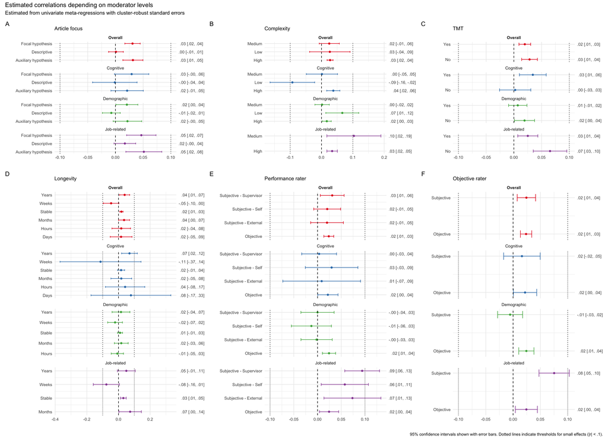

```r
p
```

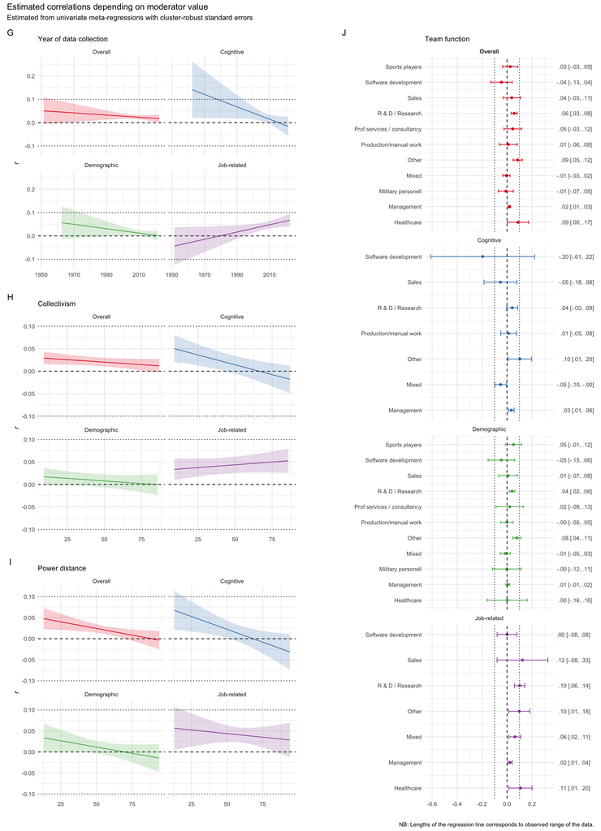

```r
pa
```

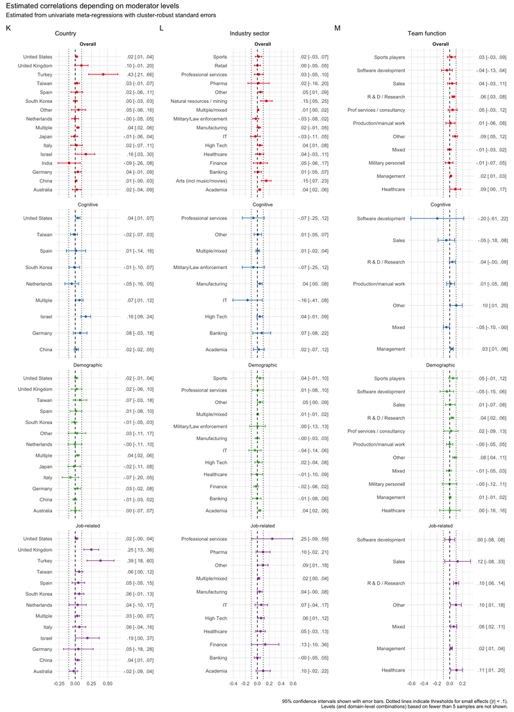

```r
p2
```

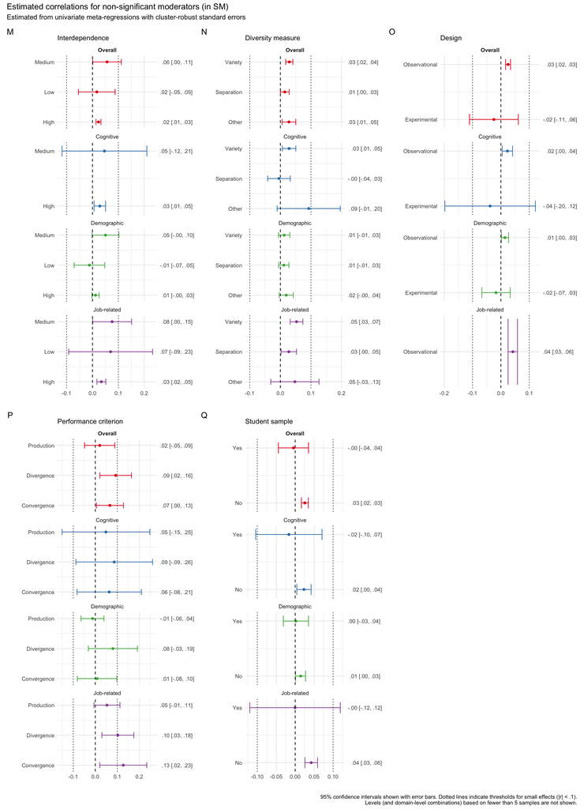

```r
p3
```

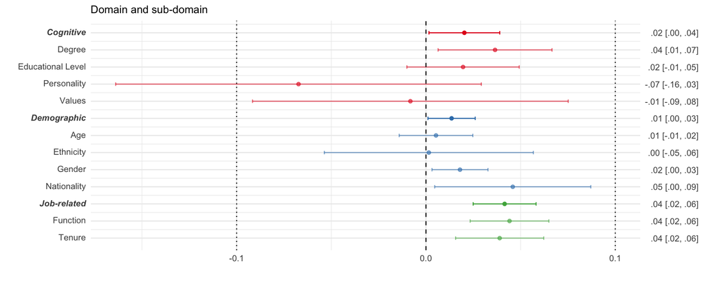

```r
p4
```